# POLI 361

October 29, 2018

## Violence and Social Media

## Today

### Recap

### Discussion

### Evidence

## Recap

### When do frames work/fail?

### Frame success and violence

## Social Media and Violence

## Does social media cause violence?

Keep in mind:

### 1. Coordination vs. Persuasion

### 2. What makes frames work:

- **credibility** (believable; credible messenger)
- **salience**

[video not shown]

## Discuss

## Difficult to say…

### 1) Do social media frames change enough?

### 2) Delayed effects of social media?

### 3) Selection into "Treatment"

## Evidence from German Facebook

## Mueller and Schwarz

### Does social-media hate speech translate into real-world behavior?

### Anti-Refugee **content** on Facebook and Anti-Refugee **violence**

- Alternative für Deutschland (AfD) Facebook Page

## Mueller and Schwarz

### Does AfD Facebook content drive anti-immigrant violence?

> If anti-refugee sentiment **spreads through Facebook**, we would expect **hate crimes** to be **more likely** to occur in municipalities with **higher exposure to social media**

## Mueller and Schwarz: Data

### Anti-Refugee Violence

- 3335 events from January 2015 to early 2017
- Reported in media outlets
- property damage, assault, arson, demonstrations

## Mueller and Schwarz: Data

### Facebook anti-Refugee rhetoric

- ~200K posts on AfD page
- use word "Refugee"

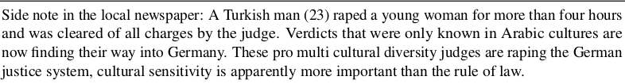

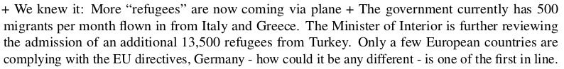

## Mueller and Schwarz: Data

### Facebook Exposure

- ~90K users on AfD Facebook page; locations for 40K
- ~63K users on Nutella Germany Facebook page; locations for 20K

Nutella captures Facebook exposure, without selection on far-right politics

## Mueller and Schwarz: Design

### (1) Compare municipalities to themselves over time

- "Control" for national trends; unchanging attributes of cities

### (2) "Treatment" of Facebook Rhetoric same for all

### (3) Exposure to "Treatment" varies with Facebook users

## Mueller and Schwarz: Design

> Do cities with **more Facebook users** have **greater increases in violence** in weeks **with anti-immigrant Facebook** activity compared to weeks **without anti-immigrant Facebook** activity than cities with **fewer facebook users**?

## Mueller and Schwarz: Results

### Compared to Frankfurt (6.5 AfD Facebook Users/10,000), Dresden (9.6 AfD Facebook Users/10,000) estimated to have 50% more attacks on refugees in a week with average anti-refugee Facebook posts.

## Mueller and Schwarz: Results

### **Results the same**

- Looking at Nutella Facebook users
- Comparing cities in same county in the same week

## Mueller and Schwarz: Results

- Effects go away when places have internet disruptions/Facebook issues
- Effects only significant for anti-Refugee rhetoric (as opposed to other topics) on AfD page
- Effects reduced when competing news (Brexit, Trump, UEFA)
- Effects of social media persist even when accounting for "traditional" media coverage

## Mueller and Schwarz: Interpretation

### Likely that social media exposure drives anto-refugee violence

### Is it **persuasion** or **coordination**?